# Getting Started with Risk Differences

```r
library(riskdiff)
library(dplyr)
```

```r
library(ggplot2)
```

## Why Risk Differences Matter in Public Health

When communicating health risks to policymakers, patients, or the public, **absolute measures** like risk differences are often more meaningful than **relative measures** like odds ratios or risk ratios.

Consider these two statements about betel nut (areca nut) chewing and cancer risk:

1. “Betel nut chewing increases the odds of cancer by 5.2 times”
2. “Betel nut chewing increases cancer risk by 12 percentage points”

The second statement is immediately actionable: in a screening group of 1,000 people, you would expect to find approximately 120 additional cancer cases among betel nut chewers compared to non-chewers. This directly informs:

- Resource allocation for screening programs
- Expected yield from targeted interventions
- Number needed to screen calculations
- Public health messaging priorities

> **Key Concept**: Risk differences represent the **additional burden of disease** attributable to an exposure. They are on the same scale as the outcome, making them intuitive for non-statistical audiences.

## Understanding the Example Data

The `riskdiff` package includes example data from a cancer screening program in Northeast India:

```r
data(cachar_sample)

# Basic structure
glimpse(cachar_sample)
```

```
#> Rows: 2,500
#> Columns: 12
#> $ id                 <int> 1, 2, 3, 4, 5, 6, 7, 8, 9, 10, 11, 12, 13, 14, 15, …
#> $ age                <int> 53, 25, 18, 28, 51, 25, 56, 20, 58, 18, 30, 64, 54,…
#> $ sex                <fct> female, male, female, female, male, female, male, m…
#> $ residence          <fct> urban slum, rural, rural, rural, rural, rural, rura…
#> $ smoking            <fct> No, No, No, No, No, No, Yes, No, No, No, No, Yes, N…
#> $ tobacco_chewing    <fct> Yes, No, No, Yes, Yes, No, Yes, No, Yes, Yes, Yes, …
#> $ areca_nut          <fct> Yes, Yes, Yes, Yes, No, No, Yes, No, Yes, Yes, No, …
#> $ alcohol            <fct> No, No, No, No, No, No, No, Yes, No, Yes, No, No, N…
#> $ abnormal_screen    <int> 0, 0, 0, 0, 0, 0, 1, 0, 1, 0, 0, 0, 0, 0, 0, 0, 0, …
#> $ head_neck_abnormal <int> 0, 0, 0, 0, 0, 0, 0, 0, 0, 0, 0, 1, 0, 0, 0, 0, 0, …
#> $ age_group          <fct> 40-60, Under 40, Under 40, Under 40, 40-60, Under 4…
#> $ tobacco_areca_both <fct> Yes, No, No, Yes, No, No, Yes, No, Yes, Yes, No, Ye…
```

```r
# Key variables for our analysis
cachar_sample %>%
  select(abnormal_screen, areca_nut, smoking, alcohol, age, sex, residence) %>%
  summary()
```

```
#>  abnormal_screen  areca_nut  smoking    alcohol         age
#>  Min.   :0.0000   No : 778   No :2168   No :1962   Min.   :18.00
#>  1st Qu.:0.0000   Yes:1722   Yes: 332   Yes: 538   1st Qu.:23.00
#>  Median :0.0000                                    Median :32.00
#>  Mean   :0.1604                                    Mean   :36.06
#>  3rd Qu.:0.0000                                    3rd Qu.:49.00
#>  Max.   :1.0000                                    Max.   :84.00
#>      sex            residence
#>  male  :1880   rural     :2158
#>  female: 620   urban     : 251
#>                urban slum:  91
#>
#>
#>
```

This dataset represents a cross-sectional screening study where:

- `abnormal_screen` = 1 indicates an abnormal cancer screening result
- `areca_nut` indicates areca (or betel) nut chewing status
- Other variables capture demographics and risk factors

## Your First Risk Difference Analysis

Let’s calculate the risk difference for cancer associated with betel nut chewing:

```r
# Simple unadjusted analysis
rd_simple <- calc_risk_diff(
  data = cachar_sample,
  outcome = "abnormal_screen",
  exposure = "areca_nut"
)
```

```
#> Warning: Unknown or uninitialised column: `on_boundary`.
```

```r
print(rd_simple)
```

```
#> Risk Difference Analysis Results (v0.1.0)
#> =========================================
#>
#> Confidence level: 95%
#> Number of comparisons: 1
#>
#>   Exposure Risk Difference           95% CI P-value    Model    N
#>  areca_nut          18.25% (15.89%, 20.57%)  <0.001 identity 2500
```

### Understanding the Output

The output shows:

- **rd**: The risk difference (e.g., 0.082 = 8.2 percentage points)
- **ci_lower, ci_upper**: 95% confidence interval bounds
- **p_value**: Test of whether the risk difference equals zero
- **model_type**: Which GLM link function successfully converged
- **n_obs**: Number of observations used in the analysis

### Interpreting Risk Differences

```r
# Let's visualize what this risk difference means
exposure_summary <- cachar_sample %>%
  group_by(areca_nut) %>%
  summarise(
    n = n(),
    cases = sum(abnormal_screen),
    risk = mean(abnormal_screen),
    se = sqrt(risk * (1 - risk) / n)
  ) %>%
  mutate(
    risk_percent = risk * 100,
    se_percent = se * 100
  )

print(exposure_summary)
```

```
#> # A tibble: 2 × 7
#>   areca_nut     n cases   risk      se risk_percent se_percent
#>   <fct>     <int> <int>  <dbl>   <dbl>        <dbl>      <dbl>
#> 1 No          778    27 0.0347 0.00656         3.47      0.656
#> 2 Yes        1722   374 0.217  0.00994        21.7       0.994
```

```r
# The risk difference is simply:
rd_value <- diff(exposure_summary$risk)
cat("Risk difference:", round(rd_value * 100, 1), "percentage points\n")
```

```
#> Risk difference: 18.2 percentage points
```

### Adjusted Analyses

Real-world associations are often confounded. Let’s adjust for age and sex:

```r
# Age and sex adjusted analysis
rd_adjusted <- calc_risk_diff(
  data = cachar_sample,
  outcome = "abnormal_screen",
  exposure = "areca_nut",
  adjust_vars = c("age", "sex")
)
print(rd_adjusted)
```

```
#> Risk Difference Analysis Results (v0.1.0)
#> =========================================
#>
#> Confidence level: 95%
#> Number of comparisons: 1
#>
#>   Exposure Risk Difference          95% CI P-value Model    N
#>  areca_nut          17.02% (2.66%, 31.38%)       —   log 2500
```

```r
# Show comparison in a readable format
cat("\n=== COMPARISON: UNADJUSTED vs ADJUSTED ===\n")
```

```
#>
#> === COMPARISON: UNADJUSTED vs ADJUSTED ===
```

```r
cat("Unadjusted Risk Difference:", sprintf("%.2f%%", rd_simple$rd * 100),
    sprintf("(%.2f%%, %.2f%%)", rd_simple$ci_lower * 100, rd_simple$ci_upper * 100), "\n")
```

```
#> Unadjusted Risk Difference: 18.25% (15.89%, 20.57%)
```

```r
cat("Adjusted Risk Difference:  ", sprintf("%.2f%%", rd_adjusted$rd * 100),
    sprintf("(%.2f%%, %.2f%%)", rd_adjusted$ci_lower * 100, rd_adjusted$ci_upper * 100), "\n")
```

```
#> Adjusted Risk Difference:   17.02% (2.66%, 31.38%)
```

```r
cat("Difference in estimates:   ", sprintf("%.2f%%", (rd_adjusted$rd - rd_simple$rd) * 100), "percentage points\n")
```

```
#> Difference in estimates:    -1.23% percentage points
```

### Stratified Analysis

Sometimes we want to know if effects differ across subgroups:

```r
# Stratified by residence (urban vs rural)
rd_stratified <- calc_risk_diff(
  data = cachar_sample,
  outcome = "abnormal_screen",
  exposure = "areca_nut",
  strata = "residence"
)
```

```
#> Warning in .transform_to_rd_robust(model, data, exposure, alpha, n_boot = 500,
#> : Confidence interval capped at ±50 percentage points due to extreme width.
#> Warning: Unknown or uninitialised column: `on_boundary`.
#> Warning in calc_risk_diff(data = cachar_sample, outcome = "abnormal_screen", :
#> 1 of 3 estimates have very wide CIs (>50 pp). Consider larger sample sizes.
```

```r
print(rd_stratified)
```

```
#> Risk Difference Analysis Results (v0.1.0)
#> =========================================
#>
#> Confidence level: 95%
#> Number of comparisons: 3
#>
#>   Exposure Risk Difference            95% CI P-value    Model    N
#>  areca_nut          18.89%  (16.28%, 21.46%)  <0.001 identity 2158
#>  areca_nut          12.50% (-37.50%, 62.50%)       —      log  251
#>  areca_nut          16.96%   (3.07%, 30.85%)   0.017 identity   91
```

- Different exposure patterns
- Access to healthcare
- Environmental co-factors

### Visualizing Your Results

A picture is worth a thousand p-values:

```r
# Stratified analysis by residence
rd_stratified <- calc_risk_diff(
  data = cachar_sample,
  outcome = "abnormal_screen",
  exposure = "areca_nut",
  strata = "residence"
)
```

```
#> Warning in .transform_to_rd_robust(model, data, exposure, alpha, n_boot = 500,
#> : Confidence interval capped at ±50 percentage points due to extreme width.
#> Warning: Unknown or uninitialised column: `on_boundary`.
#> Warning in calc_risk_diff(data = cachar_sample, outcome = "abnormal_screen", :
#> 1 of 3 estimates have very wide CIs (>50 pp). Consider larger sample sizes.
```

```r
print(rd_stratified)
```

```
#> Risk Difference Analysis Results (v0.1.0)
#> =========================================
#>
#> Confidence level: 95%
#> Number of comparisons: 3
#>
#>   Exposure Risk Difference            95% CI P-value    Model    N
#>  areca_nut          18.89%  (16.28%, 21.46%)  <0.001 identity 2158
#>  areca_nut          12.50% (-37.50%, 62.50%)       —      log  251
#>  areca_nut          16.96%   (3.07%, 30.85%)   0.017 identity   91
```

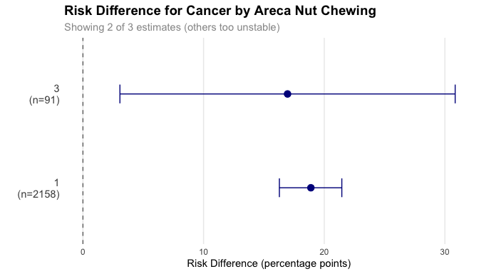

```r
# Check if estimates are stable enough for visualization
rd_summary <- rd_stratified %>%
  summarise(
    n_valid = sum(!is.na(rd)),
    max_ci_width = max((ci_upper - ci_lower) * 100, na.rm = TRUE),
    .groups = "drop"
  )

# Only create plot if we have reasonable estimates
if (rd_summary$n_valid > 0 && rd_summary$max_ci_width < 200) {
  # Use the fixed forest plot function
  plot_obj <- create_forest_plot(
    rd_stratified,
    title = "Risk Difference for Cancer by Areca Nut Chewing",
    max_ci_width = 30
  )

  if (!is.null(plot_obj)) {
    print(plot_obj)
  } else {
    cat(paste0(riskdiff:::.safe_warning()), "Could not create plot due to unstable estimates.\n")
  }
} else {
  cat(paste0(riskdiff:::.safe_warning()), "Estimates too unstable for meaningful visualization.\n")
  cat("Consider:\n")
  cat(paste0(riskdiff:::.safe_bullet()), "Larger sample sizes\n")
  cat(paste0(riskdiff:::.safe_bullet()), "Different stratification variables\n")
  cat(paste0(riskdiff:::.safe_bullet()), "Pooled analysis instead of stratification\n")

  # Show tabular results instead using the robust summary function
  formatted_results <- create_summary_table(
    rd_stratified,
    caption = "Risk Differences by Residence"
  )

  knitr::kable(formatted_results, caption = "Risk Differences by Residence")
}
```

### Common Pitfalls and Solutions

#### 1. Model Convergence Issues

The identity link GLM (which directly estimates risk differences) often fails to converge. The `riskdiff` package handles this automatically:

```r
# Force different link functions
rd_identity <- calc_risk_diff(
  cachar_sample, "abnormal_screen", "areca_nut",
  link = "identity"
)
```

```
#> Warning: Unknown or uninitialised column: `on_boundary`.
```

```r
rd_log <- calc_risk_diff(
  cachar_sample, "abnormal_screen", "areca_nut",
  link = "log"
)
# Compare model types used
cat("Identity link model type:", rd_identity$model_type, "\n")
```

```
#> Identity link model type: identity
```

```r
cat("Log link model type:", rd_log$model_type, "\n")
```

```
#> Log link model type: log
```

#### 2. Very Rare Outcomes

With rare outcomes, risk differences become very small:

```r
# Create a rare outcome (1% prevalence)
cachar_sample$rare_outcome <- rbinom(nrow(cachar_sample), 1, 0.01)

rd_rare <- calc_risk_diff(
  cachar_sample,
  "rare_outcome",
  "areca_nut"
)
```

```
#> Warning: Unknown or uninitialised column: `on_boundary`.
```

```r
print(rd_rare)
```

```
#> Risk Difference Analysis Results (v0.1.0)
#> =========================================
#>
#> Confidence level: 95%
#> Number of comparisons: 1
#>
#>   Exposure Risk Difference          95% CI P-value    Model    N
#>  areca_nut           0.55% (-0.42%, 1.39%)   0.214 identity 2500
```

> **Tip**: For very rare outcomes (<1%), consider whether risk ratios might be more appropriate for your research question.

#### 3. Missing Data

```r
# Create a copy with some missing data for demonstration
set.seed(123)  # For reproducibility
cachar_with_missing <- cachar_sample %>%
  mutate(
    # Introduce more modest missing data (~3% in age, ~2% in alcohol)
    age_with_missing = ifelse(runif(n()) < 0.03, NA, age),
    alcohol_with_missing = ifelse(runif(n()) < 0.02, NA, alcohol)
  )

# Check the missing data patterns
missing_summary <- cachar_with_missing %>%
  summarise(
    total_observations = n(),
    age_missing = sum(is.na(age_with_missing)),
    alcohol_missing = sum(is.na(alcohol_with_missing)),
    total_missing_any = sum(!complete.cases(select(., age_with_missing, alcohol_with_missing, abnormal_screen, areca_nut))),
    complete_cases = sum(complete.cases(select(., age_with_missing, alcohol_with_missing, abnormal_screen, areca_nut)))
  )

print(missing_summary)
```

```
#>   total_observations age_missing alcohol_missing total_missing_any
#> 1               2500          83              57               140
#>   complete_cases
#> 1           2360
```

```r
# Analysis with variables that have missing data
rd_missing <- calc_risk_diff(
  cachar_with_missing,
  "abnormal_screen",
  "areca_nut",
  adjust_vars = c("age_with_missing", "alcohol_with_missing")
)
# Compare with complete case analysis
rd_complete <- calc_risk_diff(
  cachar_sample,
  "abnormal_screen",
  "areca_nut",
  adjust_vars = c("age", "alcohol")
)
cat("\n=== IMPACT OF MISSING DATA ===\n")
```

```
#>
#> === IMPACT OF MISSING DATA ===
```

```r
cat("Complete data analysis (n=", rd_complete$n_obs, "): ", sprintf("%.2f%%", rd_complete$rd * 100),
    sprintf(" (%.2f%%, %.2f%%)", rd_complete$ci_lower * 100, rd_complete$ci_upper * 100), "\n")
```

```
#> Complete data analysis (n= 2500 ):  17.16%  (2.75%, 31.57%)
```

```r
# Check if missing data analysis succeeded
if (!is.na(rd_missing$rd)) {
  cat("Missing data analysis (n=", rd_missing$n_obs, "):  ", sprintf("%.2f%%", rd_missing$rd * 100),
      sprintf(" (%.2f%%, %.2f%%)", rd_missing$ci_lower * 100, rd_missing$ci_upper * 100), "\n")
  cat("Cases lost to missing data: ", rd_complete$n_obs - rd_missing$n_obs, "\n")
} else {
  cat("Missing data analysis: FAILED (insufficient data or convergence issues)\n")
  cat("Attempted to use n =", rd_missing$n_obs, "complete cases\n")
  cat("Cases lost to missing data: ", nrow(cachar_with_missing) - rd_missing$n_obs, "\n\n")

  cat("LESSON: This demonstrates why missing data can be problematic:\n")
  cat(paste0(riskdiff:::.safe_bullet()), "Listwise deletion can dramatically reduce sample size\n")
  cat(paste0(riskdiff:::.safe_bullet()), "Small samples may cause model convergence failures\n")
  cat(paste0(riskdiff:::.safe_bullet()), "Consider multiple imputation for better missing data handling\n")
  cat(paste0(riskdiff:::.safe_bullet()), "The riskdiff package gracefully handles these failures\n")
}
```

```
#> Missing data analysis: FAILED (insufficient data or convergence issues)
#> Attempted to use n = 2500 complete cases
#> Cases lost to missing data:  0
#>
#> LESSON: This demonstrates why missing data can be problematic:
#> • Listwise deletion can dramatically reduce sample size
#> • Small samples may cause model convergence failures
#> • Consider multiple imputation for better missing data handling
#> • The riskdiff package gracefully handles these failures
```

### Quick Reference

#### Basic Syntax

```r
# Example usage:
result <- calc_risk_diff(
  data = cachar_sample,           # Your dataset
  outcome = "abnormal_screen",    # Binary outcome variable (0/1)
  exposure = "areca_nut",         # Exposure of interest
  adjust_vars = c("age", "sex"),  # Variables to adjust for
  strata = "residence",           # Stratification variables
  link = "auto",                  # Link function: "auto", "identity", "log", "logit"
  alpha = 0.05,                   # Significance level (0.05 = 95% CI)
  verbose = FALSE                 # Print diagnostic messages if TRUE
)
```

#### Interpretation Guide

| Risk Difference | Interpretation | Public Health Meaning |
| --- | --- | --- |
| 0.05 (5%) | 5 percentage point increase | 50 extra cases per 1,000 screened |
| 0.01 (1%) | 1 percentage point increase | 10 extra cases per 1,000 screened |
| -0.03 (-3%) | 3 percentage point decrease | 30 fewer cases per 1,000 screened |

### When to Use Risk Differences

✅ **Use risk differences when:**

- Communicating to non-statistical audiences
- Making policy decisions about interventions
- The outcome is relatively common (>5%)
- You need to calculate number needed to treat/screen
- Comparing absolute impact across different populations

❌ **Consider alternatives when:**

- Outcome is very rare (<1%)
- You need to compare across populations with very different baseline risks
- Your research question is about biological/etiological mechanisms

## Next Steps

Now that you understand the basics:

1. See the **“Complete Example”** vignette for a full analysis workflow
2. Check the **“Technical Details”** vignette for statistical methodology
3. Use `?calc_risk_diff` for detailed function documentation

## Getting Help

- **Issues or bugs**: [https://github.com/jackmurphy2351/riskdiff/issues](https://github.com/jackmurphy2351/riskdiff)
- **Function help**: `?calc_risk_diff`, `?format_risk_diff`
- **All vignettes**: `browseVignettes("riskdiff")`